# base R vs the tidyverse

## Subsetting vs Filtering

```r
# base R
sub_b <- subset(h, genhz == "Ap")

dim(sub_b)
```

```
## [1] 211  32
```

```r
# tidyverse - dplyr
sub_t <- filter(h, genhz == "Ap")
dim(sub_t)
```

```
## [1] 211  32
```

## Ordering vs Arranging

```r
# base
with(h, h[order(cokey, hzdept_r), ])[1:4, 1:4]
```

```
##      cokey     hzname hzdept_r hzdepb_r
## 1 14880219         Ap        0       23
## 2 14880219 BE,Bt1,Bt2       23       79
## 3 14880219          C       79      152
## 4 14880222         Ap        0       23
```

```r
# tidyverse - dplyr
arrange(h, cokey, hzdept_r)[1:4, 1:4]
```

```
##      cokey     hzname hzdept_r hzdepb_r
## 1 14880219         Ap        0       23
## 2 14880219 BE,Bt1,Bt2       23       79
## 3 14880219          C       79      152
## 4 14880222         Ap        0       23
```

## Pipping

Referred too as ‘syntactic’ sugar, pipping is supposed to make code more readable, by making if read from left to right, rather than from inside out. This becomes particularly valuable when 3 or more functions combined. It also alleviates the need to overwrite existing objects.

```r
# base
pip_b <- {subset(s, drainagecl == "Well drained") ->.;
  .[order(.$nationalmusym), ]
  }
pip_b[1:4, 1:4]
```

```
##     nationalmusym compname comppct_r   compkind
## 330         1j665    Miami        40 Taxadjunct
## 328         1jt03    Miami        40 Taxadjunct
## 17          1ns3v    Miami        95 Taxadjunct
## 324         1qgv5    Miami        60 Taxadjunct
```

```r
# tidyverse
pip_t <- filter(s, drainagecl == "Well drained") %>%
  arrange(nationalmusym)
pip_t[1:4, 1:4]
```

```
##   nationalmusym compname comppct_r   compkind
## 1         1j665    Miami        40 Taxadjunct
## 2         1jt03    Miami        40 Taxadjunct
## 3         1ns3v    Miami        95 Taxadjunct
## 4         1qgv5    Miami        60 Taxadjunct
```

## Split-Combine-Apply

In lots of cases we want to know the variation within groups.

```r
# base
vars <- c("compname", "genhz")
sca_b <- {
  split(h, h[vars], drop = TRUE) ->.;
  lapply(., function(x) data.frame(
    x[vars][1, ],
    clay_min  = round(min(x$clay_r, na.rm =TRUE)),
    clay_mean = round(mean(x$clay_r, na.rm = TRUE)),
    clay_max  = round(max(x$clay_r, na.rm = TRUE))
    )) ->.;
  do.call("rbind", .)
  }
print(sca_b)
```

```
##                 compname    genhz clay_min clay_mean clay_max
## Crosby.A          Crosby        A       18        18       18
## Miami.A            Miami        A       14        20       30
## Crosby.Ap         Crosby       Ap       14        18       18
## Miami.Ap           Miami       Ap        6        18       31
## Crosby.E          Crosby        E       17        17       20
## Miami.E            Miami        E       15        19       30
## Crosby.Bt         Crosby       Bt       24        27       36
## Miami.Bt           Miami       Bt       24        30       35
## Crosby.2Bt        Crosby      2Bt       31        37       40
## Miami.2Bt          Miami      2Bt       23        30       31
## Crosby.2BCt       Crosby     2BCt       23        25       36
## Miami.2BCt         Miami     2BCt       10        23       28
## Crosby.2Cd        Crosby      2Cd       15        17       20
## Miami.2Cd          Miami      2Cd        3        16       23
## Crosby.not-used   Crosby not-used       15        26       36
## Miami.not-used     Miami not-used        3        21       31
```

```r
# tidyverse - dplyr
sca_t <- group_by(h, compname, genhz) %>%
  summarize(
    clay_min  = round(min(clay_r, na.rm =TRUE)),
    clay_mean = round(mean(clay_r, na.rm = TRUE)),
    clay_max  = round(max(clay_r, na.rm = TRUE))
  )
print(sca_t)
```

```
## # A tibble: 16 x 5
## # Groups:   compname [?]
##    compname    genhz clay_min clay_mean clay_max
##       <chr>   <fctr>    <dbl>     <dbl>    <dbl>
##  1   Crosby        A       18        18       18
##  2   Crosby       Ap       14        18       18
##  3   Crosby        E       17        17       20
##  4   Crosby       Bt       24        27       36
##  5   Crosby      2Bt       31        37       40
##  6   Crosby     2BCt       23        25       36
##  7   Crosby      2Cd       15        17       20
##  8   Crosby not-used       15        26       36
##  9    Miami        A       14        20       30
## 10    Miami       Ap        6        18       31
## 11    Miami        E       15        19       30
## 12    Miami       Bt       24        30       35
## 13    Miami      2Bt       23        30       31
## 14    Miami     2BCt       10        23       28
## 15    Miami      2Cd        3        16       23
## 16    Miami not-used        3        21       31
```

## Reshaping

In lots of instances, particularly for graphing, it’s necessary to convert the a data.frame from **wide** to **long** format.

```r
# base wide to long
vars <- c("clay_r", "sand_r", "om_r")
idvars <- c("compname", "genhz")
head(h[c(idvars, vars)])
```

```
##   compname    genhz clay_r sand_r om_r
## 1   Crosby       Ap     14     37 2.00
## 2   Crosby       Bt     36     21 0.75
## 3   Crosby not-used     20     33 0.75
## 4   Crosby       Ap     18     18 2.50
## 5   Crosby       Bt     36     21 0.75
## 6   Crosby not-used     20     33 0.75
```

```r
lo_b <- reshape(h[c("compname", "genhz", vars)],
                  direction = "long",
                  timevar = "variable", times = vars,
                  v.names = "value", varying = vars
                  )
head(lo_b) # notice the row.names
```

```
##          compname    genhz variable value id
## 1.clay_r   Crosby       Ap   clay_r    14  1
## 2.clay_r   Crosby       Bt   clay_r    36  2
## 3.clay_r   Crosby not-used   clay_r    20  3
## 4.clay_r   Crosby       Ap   clay_r    18  4
## 5.clay_r   Crosby       Bt   clay_r    36  5
## 6.clay_r   Crosby not-used   clay_r    20  6
```

```r
# tidyverse wide to long
idx <- which(names(h) %in% vars)
lo_t <- select(h, compname, idx) %>%
  gather(key = variable,
         value = value,
         - compname
         )

head(lo_t)
```

```
##   compname variable value
## 1   Crosby   sand_r    37
## 2   Crosby   sand_r    21
## 3   Crosby   sand_r    33
## 4   Crosby   sand_r    18
## 5   Crosby   sand_r    21
## 6   Crosby   sand_r    33
```

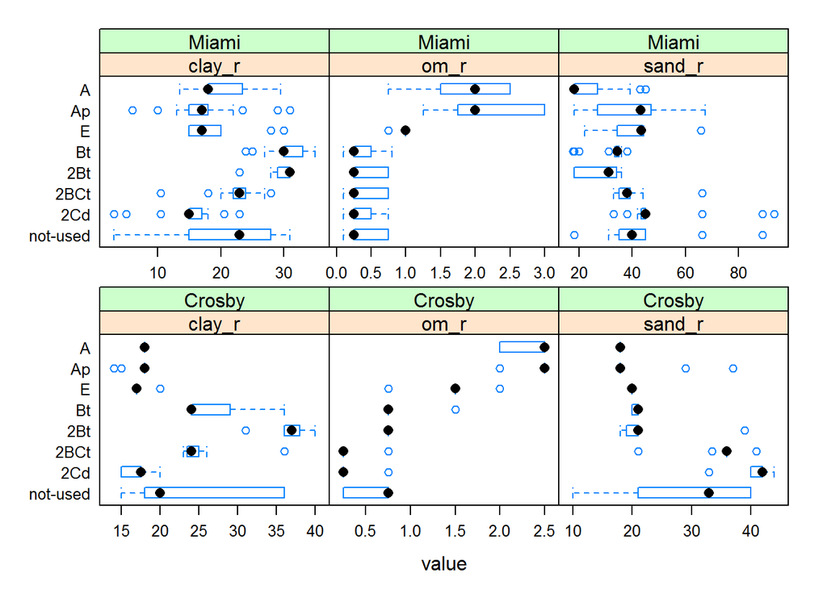

```r
comp_sort <- aggregate(value ~ compname, data = lo_b[lo_b$variable == "clay_r", ], median, na.rm = TRUE)
comp_sort <- comp_sort[order(comp_sort$value), ]
lo_b <- within(lo_b, {
  compname = factor(lo_b$compname, levels = comp_sort$compname)
  genhz = factor(genhz, levels = rev(levels(genhz)))
  })

# lattice density plot
bwplot(genhz ~ value | variable + compname, data = lo_b,
            scales = list(x = "free")
            )
```

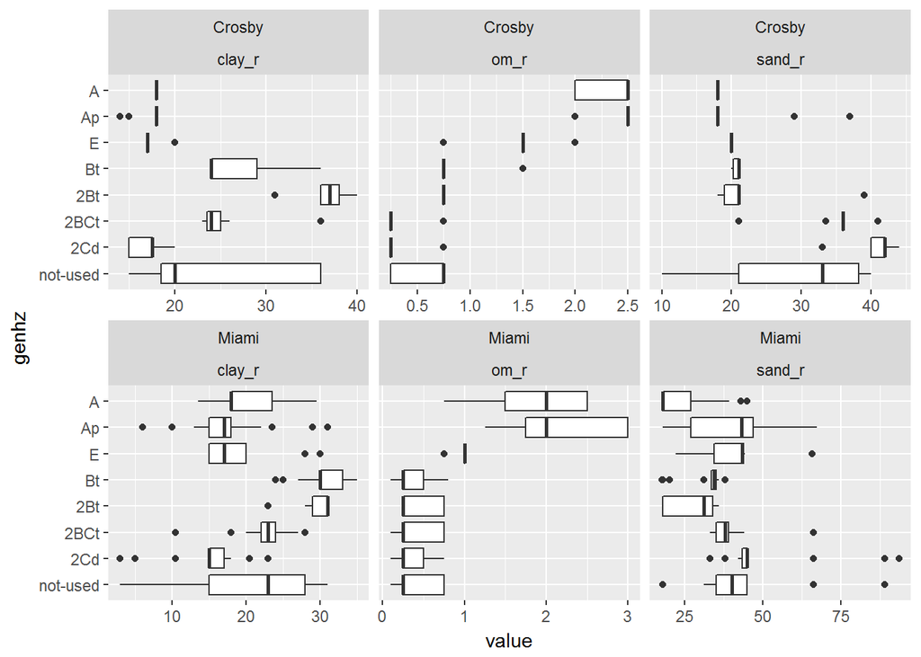

```r
# ggplot2 density plot
ggplot(lo_b, aes(x = genhz, y = value)) +
  geom_boxplot() +
  facet_wrap(~ compname + variable, scales = "free_x") +
  coord_flip()
```